# Risk Factor Analysis

## Outcome Variable

**Outcome Variable:** y_rate_len

## Predictor Variables

**Intervention Variable:** predfeed36

**Adjustment Set:**

- arm
- sex
- month
- brthmon
- W_mage
- meducyrs
- feducyrs
- hhwealth_quart
- hfoodsec
- W_mhtcm
- W_mwtkg
- W_mbmi
- vagbrth
- W_birthwt
- W_birthlen
- single
- W_nrooms
- impfloor
- impsan
- safeh20
- delta_W_mage
- delta_meducyrs
- delta_feducyrs
- delta_hhwealth_quart
- delta_hfoodsec
- delta_W_mhtcm
- delta_W_mwtkg
- delta_W_mbmi
- delta_vagbrth
- delta_W_birthwt
- delta_W_birthlen
- delta_single
- delta_W_nrooms
- delta_impfloor
- delta_impsan
- delta_safeh20

## Stratifying Variables

The analysis was stratified on these variable(s):

- agecat
- studyid
- country

## Data Summary

| agecat | studyid | country | predfeed36 | n_cell | n | outcome_variable |
| --- | --- | --- | --- | --- | --- | --- |
| 0-3 months | ki0047075b-MAL-ED | BANGLADESH | 1 | 81 | 242 | y_rate_len |
| 0-3 months | ki0047075b-MAL-ED | BANGLADESH | 0 | 161 | 242 | y_rate_len |
| 0-3 months | ki0047075b-MAL-ED | BRAZIL | 1 | 19 | 167 | y_rate_len |
| 0-3 months | ki0047075b-MAL-ED | BRAZIL | 0 | 148 | 167 | y_rate_len |
| 0-3 months | ki0047075b-MAL-ED | INDIA | 1 | 11 | 181 | y_rate_len |
| 0-3 months | ki0047075b-MAL-ED | INDIA | 0 | 170 | 181 | y_rate_len |
| 0-3 months | ki0047075b-MAL-ED | NEPAL | 1 | 8 | 154 | y_rate_len |
| 0-3 months | ki0047075b-MAL-ED | NEPAL | 0 | 146 | 154 | y_rate_len |
| 0-3 months | ki0047075b-MAL-ED | PERU | 1 | 69 | 263 | y_rate_len |
| 0-3 months | ki0047075b-MAL-ED | PERU | 0 | 194 | 263 | y_rate_len |
| 0-3 months | ki0047075b-MAL-ED | SOUTH AFRICA | 1 | 1 | 209 | y_rate_len |
| 0-3 months | ki0047075b-MAL-ED | SOUTH AFRICA | 0 | 208 | 209 | y_rate_len |
| 0-3 months | ki0047075b-MAL-ED | TANZANIA, UNITED REPUBLIC OF | 1 | 3 | 223 | y_rate_len |
| 0-3 months | ki0047075b-MAL-ED | TANZANIA, UNITED REPUBLIC OF | 0 | 220 | 223 | y_rate_len |
| 0-3 months | ki1000109-EE | PAKISTAN | 1 | 2 | 6 | y_rate_len |
| 0-3 months | ki1000109-EE | PAKISTAN | 0 | 4 | 6 | y_rate_len |
| 0-3 months | ki1113344-GMS-Nepal | NEPAL | 1 | 372 | 465 | y_rate_len |
| 0-3 months | ki1113344-GMS-Nepal | NEPAL | 0 | 93 | 465 | y_rate_len |
| 0-3 months | kiGH5241-JiVitA-3 | BANGLADESH | 1 | 7584 | 9726 | y_rate_len |
| 0-3 months | kiGH5241-JiVitA-3 | BANGLADESH | 0 | 2142 | 9726 | y_rate_len |
| 0-3 months | kiGH5241-JiVitA-4 | BANGLADESH | 1 | 1920 | 2307 | y_rate_len |
| 0-3 months | kiGH5241-JiVitA-4 | BANGLADESH | 0 | 387 | 2307 | y_rate_len |
| 3-6 months | ki0047075b-MAL-ED | BANGLADESH | 1 | 77 | 230 | y_rate_len |
| 3-6 months | ki0047075b-MAL-ED | BANGLADESH | 0 | 153 | 230 | y_rate_len |
| 3-6 months | ki0047075b-MAL-ED | BRAZIL | 1 | 25 | 208 | y_rate_len |
| 3-6 months | ki0047075b-MAL-ED | BRAZIL | 0 | 183 | 208 | y_rate_len |
| 3-6 months | ki0047075b-MAL-ED | INDIA | 1 | 17 | 228 | y_rate_len |
| 3-6 months | ki0047075b-MAL-ED | INDIA | 0 | 211 | 228 | y_rate_len |
| 3-6 months | ki0047075b-MAL-ED | NEPAL | 1 | 8 | 232 | y_rate_len |
| 3-6 months | ki0047075b-MAL-ED | NEPAL | 0 | 224 | 232 | y_rate_len |

[output cut: 150 more lines]

The following strata were considered:

- agecat: 0-3 months, studyid: ki0047075b-MAL-ED, country: BANGLADESH
- agecat: 0-3 months, studyid: ki0047075b-MAL-ED, country: BRAZIL
- agecat: 0-3 months, studyid: ki0047075b-MAL-ED, country: INDIA
- agecat: 0-3 months, studyid: ki0047075b-MAL-ED, country: NEPAL
- agecat: 0-3 months, studyid: ki0047075b-MAL-ED, country: PERU
- agecat: 0-3 months, studyid: ki0047075b-MAL-ED, country: SOUTH AFRICA
- agecat: 0-3 months, studyid: ki0047075b-MAL-ED, country: TANZANIA, UNITED REPUBLIC OF
- agecat: 0-3 months, studyid: ki1000109-EE, country: PAKISTAN
- agecat: 0-3 months, studyid: ki1113344-GMS-Nepal, country: NEPAL
- agecat: 0-3 months, studyid: kiGH5241-JiVitA-3, country: BANGLADESH
- agecat: 0-3 months, studyid: kiGH5241-JiVitA-4, country: BANGLADESH
- agecat: 12-15 months, studyid: ki0047075b-MAL-ED, country: BANGLADESH
- agecat: 12-15 months, studyid: ki0047075b-MAL-ED, country: BRAZIL
- agecat: 12-15 months, studyid: ki0047075b-MAL-ED, country: INDIA
- agecat: 12-15 months, studyid: ki0047075b-MAL-ED, country: NEPAL
- agecat: 12-15 months, studyid: ki0047075b-MAL-ED, country: PERU
- agecat: 12-15 months, studyid: ki0047075b-MAL-ED, country: SOUTH AFRICA
- agecat: 12-15 months, studyid: ki0047075b-MAL-ED, country: TANZANIA, UNITED REPUBLIC OF
- agecat: 12-15 months, studyid: ki1000109-EE, country: PAKISTAN
- agecat: 12-15 months, studyid: ki1000304b-SAS-FoodSuppl, country: INDIA
- agecat: 12-15 months, studyid: ki1113344-GMS-Nepal, country: NEPAL
- agecat: 12-15 months, studyid: ki1148112-LCNI-5, country: MALAWI
- agecat: 12-15 months, studyid: kiGH5241-JiVitA-4, country: BANGLADESH
- agecat: 15-18 months, studyid: ki0047075b-MAL-ED, country: BANGLADESH
- agecat: 15-18 months, studyid: ki0047075b-MAL-ED, country: BRAZIL
- agecat: 15-18 months, studyid: ki0047075b-MAL-ED, country: INDIA
- agecat: 15-18 months, studyid: ki0047075b-MAL-ED, country: NEPAL
- agecat: 15-18 months, studyid: ki0047075b-MAL-ED, country: PERU
- agecat: 15-18 months, studyid: ki0047075b-MAL-ED, country: SOUTH AFRICA
- agecat: 15-18 months, studyid: ki0047075b-MAL-ED, country: TANZANIA, UNITED REPUBLIC OF
- agecat: 15-18 months, studyid: ki1000109-EE, country: PAKISTAN
- agecat: 15-18 months, studyid: ki1000304b-SAS-FoodSuppl, country: INDIA
- agecat: 15-18 months, studyid: ki1113344-GMS-Nepal, country: NEPAL
- agecat: 15-18 months, studyid: ki1148112-LCNI-5, country: MALAWI
- agecat: 15-18 months, studyid: kiGH5241-JiVitA-4, country: BANGLADESH
- agecat: 18-21 months, studyid: ki0047075b-MAL-ED, country: BANGLADESH
- agecat: 18-21 months, studyid: ki0047075b-MAL-ED, country: BRAZIL
- agecat: 18-21 months, studyid: ki0047075b-MAL-ED, country: INDIA
- agecat: 18-21 months, studyid: ki0047075b-MAL-ED, country: NEPAL
- agecat: 18-21 months, studyid: ki0047075b-MAL-ED, country: PERU
- agecat: 18-21 months, studyid: ki0047075b-MAL-ED, country: SOUTH AFRICA
- agecat: 18-21 months, studyid: ki0047075b-MAL-ED, country: TANZANIA, UNITED REPUBLIC OF
- agecat: 18-21 months, studyid: ki1000109-EE, country: PAKISTAN
- agecat: 18-21 months, studyid: ki1113344-GMS-Nepal, country: NEPAL
- agecat: 18-21 months, studyid: ki1148112-LCNI-5, country: MALAWI
- agecat: 21-24 months, studyid: ki0047075b-MAL-ED, country: BANGLADESH
- agecat: 21-24 months, studyid: ki0047075b-MAL-ED, country: BRAZIL
- agecat: 21-24 months, studyid: ki0047075b-MAL-ED, country: INDIA
- agecat: 21-24 months, studyid: ki0047075b-MAL-ED, country: NEPAL
- agecat: 21-24 months, studyid: ki0047075b-MAL-ED, country: PERU
- agecat: 21-24 months, studyid: ki0047075b-MAL-ED, country: SOUTH AFRICA
- agecat: 21-24 months, studyid: ki0047075b-MAL-ED, country: TANZANIA, UNITED REPUBLIC OF
- agecat: 21-24 months, studyid: ki1000109-EE, country: PAKISTAN
- agecat: 21-24 months, studyid: ki1113344-GMS-Nepal, country: NEPAL
- agecat: 21-24 months, studyid: ki1148112-LCNI-5, country: MALAWI
- agecat: 3-6 months, studyid: ki0047075b-MAL-ED, country: BANGLADESH
- agecat: 3-6 months, studyid: ki0047075b-MAL-ED, country: BRAZIL
- agecat: 3-6 months, studyid: ki0047075b-MAL-ED, country: INDIA
- agecat: 3-6 months, studyid: ki0047075b-MAL-ED, country: NEPAL
- agecat: 3-6 months, studyid: ki0047075b-MAL-ED, country: PERU
- agecat: 3-6 months, studyid: ki0047075b-MAL-ED, country: SOUTH AFRICA
- agecat: 3-6 months, studyid: ki0047075b-MAL-ED, country: TANZANIA, UNITED REPUBLIC OF
- agecat: 3-6 months, studyid: ki1000109-EE, country: PAKISTAN
- agecat: 3-6 months, studyid: ki1113344-GMS-Nepal, country: NEPAL
- agecat: 3-6 months, studyid: kiGH5241-JiVitA-3, country: BANGLADESH
- agecat: 3-6 months, studyid: kiGH5241-JiVitA-4, country: BANGLADESH
- agecat: 6-9 months, studyid: ki0047075b-MAL-ED, country: BANGLADESH
- agecat: 6-9 months, studyid: ki0047075b-MAL-ED, country: BRAZIL
- agecat: 6-9 months, studyid: ki0047075b-MAL-ED, country: INDIA
- agecat: 6-9 months, studyid: ki0047075b-MAL-ED, country: NEPAL
- agecat: 6-9 months, studyid: ki0047075b-MAL-ED, country: PERU
- agecat: 6-9 months, studyid: ki0047075b-MAL-ED, country: SOUTH AFRICA
- agecat: 6-9 months, studyid: ki0047075b-MAL-ED, country: TANZANIA, UNITED REPUBLIC OF
- agecat: 6-9 months, studyid: ki1000109-EE, country: PAKISTAN
- agecat: 6-9 months, studyid: ki1000304b-SAS-FoodSuppl, country: INDIA
- agecat: 6-9 months, studyid: ki1113344-GMS-Nepal, country: NEPAL
- agecat: 6-9 months, studyid: ki1148112-LCNI-5, country: MALAWI
- agecat: 6-9 months, studyid: kiGH5241-JiVitA-4, country: BANGLADESH
- agecat: 9-12 months, studyid: ki0047075b-MAL-ED, country: BANGLADESH
- agecat: 9-12 months, studyid: ki0047075b-MAL-ED, country: BRAZIL
- agecat: 9-12 months, studyid: ki0047075b-MAL-ED, country: INDIA
- agecat: 9-12 months, studyid: ki0047075b-MAL-ED, country: NEPAL
- agecat: 9-12 months, studyid: ki0047075b-MAL-ED, country: PERU
- agecat: 9-12 months, studyid: ki0047075b-MAL-ED, country: SOUTH AFRICA
- agecat: 9-12 months, studyid: ki0047075b-MAL-ED, country: TANZANIA, UNITED REPUBLIC OF
- agecat: 9-12 months, studyid: ki1000109-EE, country: PAKISTAN
- agecat: 9-12 months, studyid: ki1000304b-SAS-FoodSuppl, country: INDIA
- agecat: 9-12 months, studyid: ki1113344-GMS-Nepal, country: NEPAL
- agecat: 9-12 months, studyid: ki1148112-LCNI-5, country: MALAWI
- agecat: 9-12 months, studyid: kiGH5241-JiVitA-4, country: BANGLADESH

### Dropped Strata

Some strata were dropped due to rare outcomes:

- agecat: 0-3 months, studyid: ki0047075b-MAL-ED, country: SOUTH AFRICA
- agecat: 0-3 months, studyid: ki0047075b-MAL-ED, country: TANZANIA, UNITED REPUBLIC OF
- agecat: 0-3 months, studyid: ki1000109-EE, country: PAKISTAN
- agecat: 3-6 months, studyid: ki0047075b-MAL-ED, country: SOUTH AFRICA
- agecat: 3-6 months, studyid: ki1000109-EE, country: PAKISTAN
- agecat: 6-9 months, studyid: ki0047075b-MAL-ED, country: SOUTH AFRICA
- agecat: 6-9 months, studyid: ki1000109-EE, country: PAKISTAN
- agecat: 6-9 months, studyid: ki1000304b-SAS-FoodSuppl, country: INDIA
- agecat: 9-12 months, studyid: ki0047075b-MAL-ED, country: SOUTH AFRICA
- agecat: 9-12 months, studyid: ki0047075b-MAL-ED, country: TANZANIA, UNITED REPUBLIC OF
- agecat: 9-12 months, studyid: ki1000109-EE, country: PAKISTAN
- agecat: 9-12 months, studyid: ki1000304b-SAS-FoodSuppl, country: INDIA
- agecat: 12-15 months, studyid: ki0047075b-MAL-ED, country: SOUTH AFRICA
- agecat: 12-15 months, studyid: ki0047075b-MAL-ED, country: TANZANIA, UNITED REPUBLIC OF
- agecat: 12-15 months, studyid: ki1000109-EE, country: PAKISTAN
- agecat: 12-15 months, studyid: ki1000304b-SAS-FoodSuppl, country: INDIA
- agecat: 12-15 months, studyid: ki1148112-LCNI-5, country: MALAWI
- agecat: 15-18 months, studyid: ki0047075b-MAL-ED, country: SOUTH AFRICA
- agecat: 15-18 months, studyid: ki0047075b-MAL-ED, country: TANZANIA, UNITED REPUBLIC OF
- agecat: 15-18 months, studyid: ki1000109-EE, country: PAKISTAN
- agecat: 15-18 months, studyid: ki1000304b-SAS-FoodSuppl, country: INDIA
- agecat: 15-18 months, studyid: ki1148112-LCNI-5, country: MALAWI
- agecat: 18-21 months, studyid: ki0047075b-MAL-ED, country: SOUTH AFRICA
- agecat: 18-21 months, studyid: ki0047075b-MAL-ED, country: TANZANIA, UNITED REPUBLIC OF
- agecat: 18-21 months, studyid: ki1000109-EE, country: PAKISTAN
- agecat: 21-24 months, studyid: ki0047075b-MAL-ED, country: SOUTH AFRICA
- agecat: 21-24 months, studyid: ki0047075b-MAL-ED, country: TANZANIA, UNITED REPUBLIC OF
- agecat: 21-24 months, studyid: ki1000109-EE, country: PAKISTAN

## Methods Detail

We’re interested in the causal parameters $E[Y_a]$ for all values of $a \in \mathcal{A}$. These parameters represent the mean outcome if, possibly contrary to fact, we intervened to set all units to have $A=a$. Under the randomization and positivity assumptions, these are identified by the statistical parameters $\psi_a=E_W[E_{Y|A,W}(Y|A=a,W)]$. In addition, we’re interested in the mean of $Y$, $E[Y]$ under no intervention (the observed mean). We will estimate these parameters by using SuperLearner to fit the relevant likelihood factors – $E_{Y|A,W}(Y|A=a,W)$ and $p(A=a|W)$, and then updating our likelihood fit using a joint TMLE.

For unadjusted analyses ($W=\{\}$), initial likelihoods were estimated using Lrnr_glm to estimate the simple $E(Y|A)$ and Lrnr_mean to estimate $p(A)$. For adjusted analyses, a small library containing Lrnr_glmnet, Lrnr_xgboost, and Lrnr_mean was used.

Having estimated these parameters, we will then use the delta method to estimate relative risks and attributable risks relative to a prespecified baseline level of $A$.

# Results Detail

## Results Plots

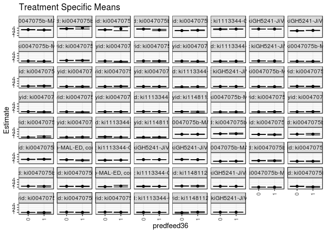

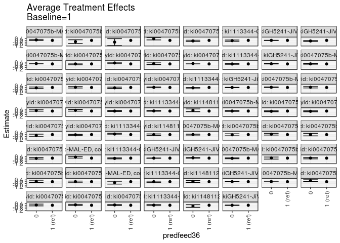

[figure not shown]

## Results Table

### Parameter: TSM

| agecat | studyid | country | intervention_level | baseline_level | estimate | ci_lower | ci_upper |
| --- | --- | --- | --- | --- | --- | --- | --- |
| 0-3 months | ki0047075b-MAL-ED | BANGLADESH | 1 | NA | 3.2640782 | 3.1583302 | 3.3698263 |
| 0-3 months | ki0047075b-MAL-ED | BANGLADESH | 0 | NA | 3.3754153 | 3.2909819 | 3.4598486 |
| 0-3 months | ki0047075b-MAL-ED | BRAZIL | 1 | NA | 4.0681230 | 3.6522885 | 4.4839575 |
| 0-3 months | ki0047075b-MAL-ED | BRAZIL | 0 | NA | 3.7747591 | 3.6606795 | 3.8888388 |
| 0-3 months | ki0047075b-MAL-ED | INDIA | 1 | NA | 3.7341705 | 2.9619145 | 4.5064266 |
| 0-3 months | ki0047075b-MAL-ED | INDIA | 0 | NA | 3.3418372 | 3.2479262 | 3.4357483 |
| 0-3 months | ki0047075b-MAL-ED | NEPAL | 1 | NA | 3.2566947 | 3.0041285 | 3.5092609 |
| 0-3 months | ki0047075b-MAL-ED | NEPAL | 0 | NA | 3.6355630 | 3.5400307 | 3.7310953 |
| 0-3 months | ki0047075b-MAL-ED | PERU | 1 | NA | 3.1425054 | 3.0102908 | 3.2747200 |
| 0-3 months | ki0047075b-MAL-ED | PERU | 0 | NA | 3.0251136 | 2.9470442 | 3.1031830 |
| 0-3 months | ki1113344-GMS-Nepal | NEPAL | 1 | NA | 3.6269049 | 3.5692333 | 3.6845765 |
| 0-3 months | ki1113344-GMS-Nepal | NEPAL | 0 | NA | 3.5711985 | 3.4411549 | 3.7012422 |
| 0-3 months | kiGH5241-JiVitA-3 | BANGLADESH | 1 | NA | 3.6463606 | 3.6322480 | 3.6604732 |
| 0-3 months | kiGH5241-JiVitA-3 | BANGLADESH | 0 | NA | 3.6500732 | 3.6248994 | 3.6752470 |
| 0-3 months | kiGH5241-JiVitA-4 | BANGLADESH | 1 | NA | 3.0794777 | 3.0261384 | 3.1328171 |
| 0-3 months | kiGH5241-JiVitA-4 | BANGLADESH | 0 | NA | 2.9474161 | 2.8376967 | 3.0571354 |
| 3-6 months | ki0047075b-MAL-ED | BANGLADESH | 1 | NA | 1.9284765 | 1.8367139 | 2.0202391 |
| 3-6 months | ki0047075b-MAL-ED | BANGLADESH | 0 | NA | 1.9306029 | 1.8716628 | 1.9895430 |
| 3-6 months | ki0047075b-MAL-ED | BRAZIL | 1 | NA | 2.1862546 | 1.9766907 | 2.3958184 |
| 3-6 months | ki0047075b-MAL-ED | BRAZIL | 0 | NA | 2.1407516 | 2.0555565 | 2.2259467 |
| 3-6 months | ki0047075b-MAL-ED | INDIA | 1 | NA | 1.7893525 | 1.6091491 | 1.9695559 |
| 3-6 months | ki0047075b-MAL-ED | INDIA | 0 | NA | 1.8813276 | 1.8145811 | 1.9480740 |
| 3-6 months | ki0047075b-MAL-ED | NEPAL | 1 | NA | 1.9686909 | 1.6865490 | 2.2508327 |
| 3-6 months | ki0047075b-MAL-ED | NEPAL | 0 | NA | 1.9659877 | 1.9085533 | 2.0234221 |
| 3-6 months | ki0047075b-MAL-ED | PERU | 1 | NA | 2.0519207 | 1.9128342 | 2.1910072 |
| 3-6 months | ki0047075b-MAL-ED | PERU | 0 | NA | 1.9944775 | 1.9199153 | 2.0690397 |
| 3-6 months | ki0047075b-MAL-ED | TANZANIA, UNITED REPUBLIC OF | 1 | NA | 1.6207289 | 1.4299522 | 1.8115056 |
| 3-6 months | ki0047075b-MAL-ED | TANZANIA, UNITED REPUBLIC OF | 0 | NA | 1.8334280 | 1.7636111 | 1.9032449 |
| 3-6 months | ki1113344-GMS-Nepal | NEPAL | 1 | NA | 1.7188164 | 1.6752219 | 1.7624110 |
| 3-6 months | ki1113344-GMS-Nepal | NEPAL | 0 | NA | 1.6642690 | 1.5668402 | 1.7616978 |

[output cut: 94 more lines]

### Parameter: E(Y)

| agecat | studyid | country | intervention_level | baseline_level | estimate | ci_lower | ci_upper |
| --- | --- | --- | --- | --- | --- | --- | --- |
| 0-3 months | ki0047075b-MAL-ED | BANGLADESH | NA | NA | 3.3402171 | 3.2743239 | 3.4061103 |
| 0-3 months | ki0047075b-MAL-ED | BRAZIL | NA | NA | 3.8085653 | 3.6991781 | 3.9179525 |
| 0-3 months | ki0047075b-MAL-ED | INDIA | NA | NA | 3.3499072 | 3.2511340 | 3.4486803 |
| 0-3 months | ki0047075b-MAL-ED | NEPAL | NA | NA | 3.6158815 | 3.5234019 | 3.7083612 |
| 0-3 months | ki0047075b-MAL-ED | PERU | NA | NA | 3.0490404 | 2.9824173 | 3.1156636 |
| 0-3 months | ki1113344-GMS-Nepal | NEPAL | NA | NA | 3.6173812 | 3.5643204 | 3.6704421 |
| 0-3 months | kiGH5241-JiVitA-3 | BANGLADESH | NA | NA | 3.6471006 | 3.6339981 | 3.6602031 |
| 0-3 months | kiGH5241-JiVitA-4 | BANGLADESH | NA | NA | 3.0560787 | 3.0061448 | 3.1060127 |
| 3-6 months | ki0047075b-MAL-ED | BANGLADESH | NA | NA | 1.9261033 | 1.8757410 | 1.9764655 |
| 3-6 months | ki0047075b-MAL-ED | BRAZIL | NA | NA | 2.1460815 | 2.0668679 | 2.2252951 |
| 3-6 months | ki0047075b-MAL-ED | INDIA | NA | NA | 1.8848530 | 1.8216037 | 1.9481024 |
| 3-6 months | ki0047075b-MAL-ED | NEPAL | NA | NA | 1.9660809 | 1.9097800 | 2.0223819 |
| 3-6 months | ki0047075b-MAL-ED | PERU | NA | NA | 2.0156821 | 1.9494666 | 2.0818976 |
| 3-6 months | ki0047075b-MAL-ED | TANZANIA, UNITED REPUBLIC OF | NA | NA | 1.8289025 | 1.7605509 | 1.8972540 |
| 3-6 months | ki1113344-GMS-Nepal | NEPAL | NA | NA | 1.7085606 | 1.6688133 | 1.7483079 |
| 3-6 months | kiGH5241-JiVitA-3 | BANGLADESH | NA | NA | 1.9103432 | 1.8959278 | 1.9247587 |
| 3-6 months | kiGH5241-JiVitA-4 | BANGLADESH | NA | NA | 1.8946008 | 1.8642204 | 1.9249811 |
| 6-9 months | ki0047075b-MAL-ED | BANGLADESH | NA | NA | 1.2480451 | 1.2083209 | 1.2877694 |
| 6-9 months | ki0047075b-MAL-ED | BRAZIL | NA | NA | 1.4831159 | 1.4026580 | 1.5635738 |
| 6-9 months | ki0047075b-MAL-ED | INDIA | NA | NA | 1.2403346 | 1.1889010 | 1.2917682 |
| 6-9 months | ki0047075b-MAL-ED | NEPAL | NA | NA | 1.3587924 | 1.3145651 | 1.4030198 |
| 6-9 months | ki0047075b-MAL-ED | PERU | NA | NA | 1.3199965 | 1.2656612 | 1.3743319 |
| 6-9 months | ki0047075b-MAL-ED | TANZANIA, UNITED REPUBLIC OF | NA | NA | 1.1929853 | 1.1149435 | 1.2710272 |
| 6-9 months | ki1113344-GMS-Nepal | NEPAL | NA | NA | 1.3144775 | 1.2731267 | 1.3558284 |
| 6-9 months | ki1148112-LCNI-5 | MALAWI | NA | NA | 1.4372604 | 1.3755150 | 1.4990057 |
| 6-9 months | kiGH5241-JiVitA-4 | BANGLADESH | NA | NA | 1.3252108 | 1.3036943 | 1.3467274 |
| 9-12 months | ki0047075b-MAL-ED | BANGLADESH | NA | NA | 0.9896446 | 0.9509752 | 1.0283140 |
| 9-12 months | ki0047075b-MAL-ED | BRAZIL | NA | NA | 1.2982559 | 1.2240694 | 1.3724425 |
| 9-12 months | ki0047075b-MAL-ED | INDIA | NA | NA | 0.9798686 | 0.9411954 | 1.0185419 |
| 9-12 months | ki0047075b-MAL-ED | NEPAL | NA | NA | 1.0883592 | 1.0474563 | 1.1292621 |
| 9-12 months | ki0047075b-MAL-ED | PERU | NA | NA | 1.0985124 | 1.0475959 | 1.1494289 |
| 9-12 months | ki1113344-GMS-Nepal | NEPAL | NA | NA | 0.9984152 | 0.9640726 | 1.0327578 |
| 9-12 months | ki1148112-LCNI-5 | MALAWI | NA | NA | 0.9706344 | 0.8246089 | 1.1166600 |
| 9-12 months | kiGH5241-JiVitA-4 | BANGLADESH | NA | NA | 1.0692570 | 1.0496985 | 1.0888155 |
| 12-15 months | ki0047075b-MAL-ED | BANGLADESH | NA | NA | 0.9141004 | 0.8737459 | 0.9544550 |
| 12-15 months | ki0047075b-MAL-ED | BRAZIL | NA | NA | 1.1421774 | 1.0831447 | 1.2012100 |
| 12-15 months | ki0047075b-MAL-ED | INDIA | NA | NA | 0.9075845 | 0.8681682 | 0.9470009 |
| 12-15 months | ki0047075b-MAL-ED | NEPAL | NA | NA | 0.9512824 | 0.9117179 | 0.9908469 |
| 12-15 months | ki0047075b-MAL-ED | PERU | NA | NA | 0.8917280 | 0.8454370 | 0.9380189 |
| 12-15 months | ki1113344-GMS-Nepal | NEPAL | NA | NA | 0.8702474 | 0.8441404 | 0.8963544 |
| 12-15 months | kiGH5241-JiVitA-4 | BANGLADESH | NA | NA | 0.9373418 | 0.9196982 | 0.9549854 |
| 15-18 months | ki0047075b-MAL-ED | BANGLADESH | NA | NA | 0.8241226 | 0.7871907 | 0.8610544 |
| 15-18 months | ki0047075b-MAL-ED | BRAZIL | NA | NA | 1.0021114 | 0.9429996 | 1.0612232 |
| 15-18 months | ki0047075b-MAL-ED | INDIA | NA | NA | 0.8476806 | 0.8113849 | 0.8839763 |
| 15-18 months | ki0047075b-MAL-ED | NEPAL | NA | NA | 0.8406068 | 0.7989917 | 0.8822220 |
| 15-18 months | ki0047075b-MAL-ED | PERU | NA | NA | 0.8534307 | 0.8111406 | 0.8957208 |
| 15-18 months | ki1113344-GMS-Nepal | NEPAL | NA | NA | 0.7596809 | 0.7265174 | 0.7928444 |
| 15-18 months | kiGH5241-JiVitA-4 | BANGLADESH | NA | NA | 0.8576466 | 0.8394619 | 0.8758313 |
| 18-21 months | ki0047075b-MAL-ED | BANGLADESH | NA | NA | 0.8133847 | 0.7790076 | 0.8477619 |
| 18-21 months | ki0047075b-MAL-ED | BRAZIL | NA | NA | 0.9160758 | 0.8452655 | 0.9868862 |
| 18-21 months | ki0047075b-MAL-ED | INDIA | NA | NA | 0.8759623 | 0.8406388 | 0.9112858 |
| 18-21 months | ki0047075b-MAL-ED | NEPAL | NA | NA | 0.8178484 | 0.7795814 | 0.8561153 |
| 18-21 months | ki0047075b-MAL-ED | PERU | NA | NA | 0.8414439 | 0.7967949 | 0.8860929 |
| 18-21 months | ki1113344-GMS-Nepal | NEPAL | NA | NA | 0.9045343 | 0.8683581 | 0.9407104 |
| 18-21 months | ki1148112-LCNI-5 | MALAWI | NA | NA | 0.8419773 | 0.7481346 | 0.9358201 |
| 21-24 months | ki0047075b-MAL-ED | BANGLADESH | NA | NA | 0.7694183 | 0.7339448 | 0.8048918 |
| 21-24 months | ki0047075b-MAL-ED | BRAZIL | NA | NA | 0.7961519 | 0.7521041 | 0.8401997 |
| 21-24 months | ki0047075b-MAL-ED | INDIA | NA | NA | 0.8269217 | 0.7961503 | 0.8576932 |
| 21-24 months | ki0047075b-MAL-ED | NEPAL | NA | NA | 0.7833446 | 0.7424130 | 0.8242761 |
| 21-24 months | ki0047075b-MAL-ED | PERU | NA | NA | 0.7610506 | 0.7141593 | 0.8079419 |
| 21-24 months | ki1113344-GMS-Nepal | NEPAL | NA | NA | 0.7920360 | 0.7445193 | 0.8395527 |
| 21-24 months | ki1148112-LCNI-5 | MALAWI | NA | NA | 0.7342569 | 0.6662316 | 0.8022822 |

### Parameter: ATE

| agecat | studyid | country | intervention_level | baseline_level | estimate | ci_lower | ci_upper |
| --- | --- | --- | --- | --- | --- | --- | --- |
| 0-3 months | ki0047075b-MAL-ED | BANGLADESH | 1 | 1 | 0.0000000 | 0.0000000 | 0.0000000 |
| 0-3 months | ki0047075b-MAL-ED | BANGLADESH | 0 | 1 | 0.1113370 | -0.0240918 | 0.2467658 |
| 0-3 months | ki0047075b-MAL-ED | BRAZIL | 1 | 1 | 0.0000000 | 0.0000000 | 0.0000000 |
| 0-3 months | ki0047075b-MAL-ED | BRAZIL | 0 | 1 | -0.2933639 | -0.7239192 | 0.1371914 |
| 0-3 months | ki0047075b-MAL-ED | INDIA | 1 | 1 | 0.0000000 | 0.0000000 | 0.0000000 |
| 0-3 months | ki0047075b-MAL-ED | INDIA | 0 | 1 | -0.3923333 | -1.1712454 | 0.3865788 |
| 0-3 months | ki0047075b-MAL-ED | NEPAL | 1 | 1 | 0.0000000 | 0.0000000 | 0.0000000 |
| 0-3 months | ki0047075b-MAL-ED | NEPAL | 0 | 1 | 0.3788683 | 0.1088384 | 0.6488981 |
| 0-3 months | ki0047075b-MAL-ED | PERU | 1 | 1 | 0.0000000 | 0.0000000 | 0.0000000 |
| 0-3 months | ki0047075b-MAL-ED | PERU | 0 | 1 | -0.1173918 | -0.2730785 | 0.0382950 |
| 0-3 months | ki1113344-GMS-Nepal | NEPAL | 1 | 1 | 0.0000000 | 0.0000000 | 0.0000000 |
| 0-3 months | ki1113344-GMS-Nepal | NEPAL | 0 | 1 | -0.0557063 | -0.1973873 | 0.0859746 |
| 0-3 months | kiGH5241-JiVitA-3 | BANGLADESH | 1 | 1 | 0.0000000 | 0.0000000 | 0.0000000 |
| 0-3 months | kiGH5241-JiVitA-3 | BANGLADESH | 0 | 1 | 0.0037126 | -0.0230654 | 0.0304907 |
| 0-3 months | kiGH5241-JiVitA-4 | BANGLADESH | 1 | 1 | 0.0000000 | 0.0000000 | 0.0000000 |
| 0-3 months | kiGH5241-JiVitA-4 | BANGLADESH | 0 | 1 | -0.1320617 | -0.2491881 | -0.0149352 |
| 3-6 months | ki0047075b-MAL-ED | BANGLADESH | 1 | 1 | 0.0000000 | 0.0000000 | 0.0000000 |
| 3-6 months | ki0047075b-MAL-ED | BANGLADESH | 0 | 1 | 0.0021264 | -0.1076850 | 0.1119378 |
| 3-6 months | ki0047075b-MAL-ED | BRAZIL | 1 | 1 | 0.0000000 | 0.0000000 | 0.0000000 |
| 3-6 months | ki0047075b-MAL-ED | BRAZIL | 0 | 1 | -0.0455029 | -0.2717066 | 0.1807008 |
| 3-6 months | ki0047075b-MAL-ED | INDIA | 1 | 1 | 0.0000000 | 0.0000000 | 0.0000000 |
| 3-6 months | ki0047075b-MAL-ED | INDIA | 0 | 1 | 0.0919750 | -0.1004181 | 0.2843682 |
| 3-6 months | ki0047075b-MAL-ED | NEPAL | 1 | 1 | 0.0000000 | 0.0000000 | 0.0000000 |
| 3-6 months | ki0047075b-MAL-ED | NEPAL | 0 | 1 | -0.0027032 | -0.2906315 | 0.2852252 |
| 3-6 months | ki0047075b-MAL-ED | PERU | 1 | 1 | 0.0000000 | 0.0000000 | 0.0000000 |
| 3-6 months | ki0047075b-MAL-ED | PERU | 0 | 1 | -0.0574431 | -0.2141423 | 0.0992560 |
| 3-6 months | ki0047075b-MAL-ED | TANZANIA, UNITED REPUBLIC OF | 1 | 1 | 0.0000000 | 0.0000000 | 0.0000000 |
| 3-6 months | ki0047075b-MAL-ED | TANZANIA, UNITED REPUBLIC OF | 0 | 1 | 0.2126991 | 0.0095485 | 0.4158496 |
| 3-6 months | ki1113344-GMS-Nepal | NEPAL | 1 | 1 | 0.0000000 | 0.0000000 | 0.0000000 |
| 3-6 months | ki1113344-GMS-Nepal | NEPAL | 0 | 1 | -0.0545474 | -0.1615724 | 0.0524776 |

[output cut: 94 more lines]

### Parameter: PAR

| agecat | studyid | country | intervention_level | baseline_level | estimate | ci_lower | ci_upper |
| --- | --- | --- | --- | --- | --- | --- | --- |
| 0-3 months | ki0047075b-MAL-ED | BANGLADESH | 1 | NA | 0.0761388 | -0.0154906 | 0.1677683 |
| 0-3 months | ki0047075b-MAL-ED | BRAZIL | 1 | NA | -0.2595577 | -0.6498026 | 0.1306871 |
| 0-3 months | ki0047075b-MAL-ED | INDIA | 1 | NA | -0.3842634 | -1.1183100 | 0.3497833 |
| 0-3 months | ki0047075b-MAL-ED | NEPAL | 1 | NA | 0.3591868 | 0.1028381 | 0.6155356 |
| 0-3 months | ki0047075b-MAL-ED | PERU | 1 | NA | -0.0934649 | -0.2084775 | 0.0215476 |
| 0-3 months | ki1113344-GMS-Nepal | NEPAL | 1 | NA | -0.0095236 | -0.0376421 | 0.0185948 |
| 0-3 months | kiGH5241-JiVitA-3 | BANGLADESH | 1 | NA | 0.0007400 | -0.0051578 | 0.0066378 |
| 0-3 months | kiGH5241-JiVitA-4 | BANGLADESH | 1 | NA | -0.0233990 | -0.0433837 | -0.0034143 |
| 3-6 months | ki0047075b-MAL-ED | BANGLADESH | 1 | NA | -0.0023732 | -0.0765099 | 0.0717634 |
| 3-6 months | ki0047075b-MAL-ED | BRAZIL | 1 | NA | -0.0401730 | -0.2395651 | 0.1592191 |
| 3-6 months | ki0047075b-MAL-ED | INDIA | 1 | NA | 0.0955005 | -0.0836942 | 0.2746952 |
| 3-6 months | ki0047075b-MAL-ED | NEPAL | 1 | NA | -0.0026100 | -0.2806098 | 0.2753898 |
| 3-6 months | ki0047075b-MAL-ED | PERU | 1 | NA | -0.0362385 | -0.1522571 | 0.0797801 |
| 3-6 months | ki0047075b-MAL-ED | TANZANIA, UNITED REPUBLIC OF | 1 | NA | 0.2081736 | 0.0100628 | 0.4062844 |
| 3-6 months | ki1113344-GMS-Nepal | NEPAL | 1 | NA | -0.0102559 | -0.0319920 | 0.0114803 |
| 3-6 months | kiGH5241-JiVitA-3 | BANGLADESH | 1 | NA | 0.0003856 | -0.0067479 | 0.0075192 |
| 3-6 months | kiGH5241-JiVitA-4 | BANGLADESH | 1 | NA | 0.0113810 | -0.0017995 | 0.0245615 |
| 6-9 months | ki0047075b-MAL-ED | BANGLADESH | 1 | NA | -0.0276646 | -0.0931658 | 0.0378367 |
| 6-9 months | ki0047075b-MAL-ED | BRAZIL | 1 | NA | 0.0154120 | -0.1864893 | 0.2173133 |
| 6-9 months | ki0047075b-MAL-ED | INDIA | 1 | NA | 0.0065146 | -0.1529475 | 0.1659767 |
| 6-9 months | ki0047075b-MAL-ED | NEPAL | 1 | NA | 0.0721413 | -0.1787411 | 0.3230238 |
| 6-9 months | ki0047075b-MAL-ED | PERU | 1 | NA | 0.0108234 | -0.0847880 | 0.1064348 |
| 6-9 months | ki0047075b-MAL-ED | TANZANIA, UNITED REPUBLIC OF | 1 | NA | -0.2091025 | -0.5257761 | 0.1075711 |
| 6-9 months | ki1113344-GMS-Nepal | NEPAL | 1 | NA | 0.0033647 | -0.0231375 | 0.0298668 |
| 6-9 months | ki1148112-LCNI-5 | MALAWI | 1 | NA | 0.0438138 | -0.1449595 | 0.2325872 |
| 6-9 months | kiGH5241-JiVitA-4 | BANGLADESH | 1 | NA | 0.0009941 | -0.0094738 | 0.0114620 |
| 9-12 months | ki0047075b-MAL-ED | BANGLADESH | 1 | NA | 0.0227309 | -0.0330846 | 0.0785463 |
| 9-12 months | ki0047075b-MAL-ED | BRAZIL | 1 | NA | 0.2232390 | 0.0402384 | 0.4062396 |
| 9-12 months | ki0047075b-MAL-ED | INDIA | 1 | NA | 0.0531377 | -0.1348207 | 0.2410960 |
| 9-12 months | ki0047075b-MAL-ED | NEPAL | 1 | NA | 0.0919867 | -0.0168464 | 0.2008198 |
| 9-12 months | ki0047075b-MAL-ED | PERU | 1 | NA | 0.0608707 | -0.0189699 | 0.1407113 |
| 9-12 months | ki1113344-GMS-Nepal | NEPAL | 1 | NA | 0.0035740 | -0.0182076 | 0.0253556 |
| 9-12 months | ki1148112-LCNI-5 | MALAWI | 1 | NA | -0.0976334 | -0.3046894 | 0.1094226 |
| 9-12 months | kiGH5241-JiVitA-4 | BANGLADESH | 1 | NA | 0.0010619 | -0.0089953 | 0.0111191 |
| 12-15 months | ki0047075b-MAL-ED | BANGLADESH | 1 | NA | 0.0556537 | 0.0005613 | 0.1107460 |
| 12-15 months | ki0047075b-MAL-ED | BRAZIL | 1 | NA | -0.0096375 | -0.1704268 | 0.1511518 |
| 12-15 months | ki0047075b-MAL-ED | INDIA | 1 | NA | 0.2063252 | 0.0448464 | 0.3678040 |
| 12-15 months | ki0047075b-MAL-ED | NEPAL | 1 | NA | 0.0423720 | -0.1523408 | 0.2370847 |
| 12-15 months | ki0047075b-MAL-ED | PERU | 1 | NA | 0.0691261 | -0.0014232 | 0.1396753 |
| 12-15 months | ki1113344-GMS-Nepal | NEPAL | 1 | NA | -0.0020240 | -0.0162205 | 0.0121726 |
| 12-15 months | kiGH5241-JiVitA-4 | BANGLADESH | 1 | NA | 0.0071761 | -0.0028921 | 0.0172442 |
| 15-18 months | ki0047075b-MAL-ED | BANGLADESH | 1 | NA | 0.0086206 | -0.0433446 | 0.0605857 |
| 15-18 months | ki0047075b-MAL-ED | BRAZIL | 1 | NA | -0.0594046 | -0.2183053 | 0.0994961 |
| 15-18 months | ki0047075b-MAL-ED | INDIA | 1 | NA | 0.0370962 | -0.1068119 | 0.1810044 |
| 15-18 months | ki0047075b-MAL-ED | NEPAL | 1 | NA | -0.0680421 | -0.2179979 | 0.0819138 |
| 15-18 months | ki0047075b-MAL-ED | PERU | 1 | NA | 0.0231527 | -0.0423833 | 0.0886886 |
| 15-18 months | ki1113344-GMS-Nepal | NEPAL | 1 | NA | -0.0167429 | -0.0301339 | -0.0033518 |
| 15-18 months | kiGH5241-JiVitA-4 | BANGLADESH | 1 | NA | 0.0011069 | -0.0079743 | 0.0101881 |
| 18-21 months | ki0047075b-MAL-ED | BANGLADESH | 1 | NA | 0.0281723 | -0.0232093 | 0.0795539 |
| 18-21 months | ki0047075b-MAL-ED | BRAZIL | 1 | NA | 0.0373452 | -0.0918361 | 0.1665265 |
| 18-21 months | ki0047075b-MAL-ED | INDIA | 1 | NA | 0.1177467 | -0.0288713 | 0.2643648 |
| 18-21 months | ki0047075b-MAL-ED | NEPAL | 1 | NA | 0.1571422 | -0.0209289 | 0.3352134 |
| 18-21 months | ki0047075b-MAL-ED | PERU | 1 | NA | -0.0070018 | -0.0846715 | 0.0706680 |
| 18-21 months | ki1113344-GMS-Nepal | NEPAL | 1 | NA | 0.0049151 | -0.0086346 | 0.0184648 |
| 18-21 months | ki1148112-LCNI-5 | MALAWI | 1 | NA | 0.1204299 | -0.1216344 | 0.3624943 |
| 21-24 months | ki0047075b-MAL-ED | BANGLADESH | 1 | NA | -0.0014139 | -0.0545306 | 0.0517027 |
| 21-24 months | ki0047075b-MAL-ED | BRAZIL | 1 | NA | -0.0468411 | -0.1403032 | 0.0466209 |
| 21-24 months | ki0047075b-MAL-ED | INDIA | 1 | NA | -0.0543050 | -0.1566726 | 0.0480626 |
| 21-24 months | ki0047075b-MAL-ED | NEPAL | 1 | NA | -0.1768696 | -0.4510639 | 0.0973247 |
| 21-24 months | ki0047075b-MAL-ED | PERU | 1 | NA | -0.0390977 | -0.1245247 | 0.0463292 |
| 21-24 months | ki1113344-GMS-Nepal | NEPAL | 1 | NA | 0.0231441 | -0.0061514 | 0.0524396 |
| 21-24 months | ki1148112-LCNI-5 | MALAWI | 1 | NA | -0.0076049 | -0.1429495 | 0.1277396 |